# Does Information Security Training Prevent Cybercrime Does U.K. Companies

Andrew Chait - Final Draft

December 6, 2018

# Literature Review and Question:

Cybercrime is the forceful penetration into a computer system with the intention of causing harm or stealing information. The most popular type of cybercrime is credential fraud, which is the misuse of account details to defraud financial and payment systems (Singer and Friedman, 2014). Types of cyber-attacks that affect larger corporationscome in the form of phishing emails (fake emails intended to trick people into giving information or access to a system) and breaches of system security to steal information. It’s clear that cybercrime is a threat to corporations, and therefore corporations should do everything they can to try and prevent it. Understanding what cybercriminals are trying to achieve isn’t enough however. A scope of how much cybercrime occurs is important in protecting against it. For example, all cybercrimes reported in NYC alone would take up 1/4th of the nation’s digital law enforcement capacity, which means that in 5-10 years we may find ourselves in an unrecoverable situation if we don’t take dramatic action soon (Gogolin, 2010). Gogolin’s prediction about the future paints a representative picture for how wide spread cybercrime is and helps support the idea that we should be examining how effective our current anti-cybercrime measures are. It’s been reported that secure software has not advanced much in the last 5 years, which means the degree of insecurity has risen with it (Libicki, et. Al., 2014). Since there is no official government entity protecting companies from cybercriminals, so it’s up to each company to not only set up defenses but also train employees against these digital attacks.

I’ve also learned that the proportion of adult internet users experiencing cybercrime has seen a statistically significant increase from 2007 where it was only 2% of all users to 2012 where there is now a total of 7% (McGuire and Dowling, 2013), which could have a direct correlation to the lack in security software advancements.An article posted by the UK Government discussing security breaches in organizations and charities within the country says that they found that among large businesses 72% have had some form of data breach, and among large charities that 73% have had a data breach (Vaidya, 2018). The high number of effected organizations across the UK is very alarming and provides a great population to get my sample from. Since this is such a large issue in the UK, getting data on UK corporations will be a great tool to analyze the effectiveness of cybersecurity in corporations. This data will help me determine which industries are the most vulnerable, if companies are training their employees in practices that would lower the success rate of an attacker, and how many attacks are still committed a year despite the training. This data will also help me determine if there is any effect when training employees and implementing measures against cybercrime. The question I’m trying to answer is if the current countermeasures that corporations take to defend themselves from cybercrime relates with the number of successful attacks.

**Null Hypothesis:** Current cybercrime countermeasures do not have an association with the number of successful cybercrime attacks.

**Alternative Hypothesis:** Current cybercrime countermeasures do have an association with the number of successful cybercrime attacks.

# Methods

The data I’m using was gathered by the UK Department for Business, Energy, and Industrial Strategy (https://www.europeandataportal.eu/data/dataset/information-security-breaches-survey).

Initially looking at the data I noticed that the vast majority of these entries were incomplete. Due to the incomplete data not being able to help me with my analysis, I decided to prune down the data to just 70 entries which had complete data. While this felt like a good representative number to look into my question, about 15 of these entries had data mostly consisting of “I don’t know” entries, which wouldn’t serve to help answer the question being proposed. After pruning these unhelpful selections down, I have 53 entries in my data that are completely answered with informative data. After this I looked at the range of answers available for each column.

For example, when looking at sectors of industry types I was able to see:

```r
library(tidyr)
library(dplyr)

mySectors <- data %>%
  group_by(Sector) %>%
  summarise(Freq = n())
mySectors
```

```
## # A tibble: 14 x 2
##    Sector                        Freq
##    <fct>                        <int>
##  1 Banking                          2
##  2 Education                        6
##  3 Government                       7
##  4 Health                           5
##  5 Insurance                        2
##  6 Leisure and entertainment        1
##  7 Manufacturing                    1
##  8 Other                            8
##  9 Pharmaceutical                   2
## 10 Retail                           1
## 11 Services                         1
## 12 Technology                      12
## 13 Telecommunications               2
## 14 Utilities, energy and mining     3
```

Which shows that I have 14 different industries to look at, which seemed like a good representation for the population of industry types in the UK. To avoid bias I didn’t restrict any type of industry, or remove the rows in which entries left something as “I don’t know” (unless that was the majority of their answers). I also trimmed my data down to only look at the questions that reflected the companies prority in information security (training, staff understanding, and expendature), as well as questions that only reflected the number of times different attacks occured. I removed questions that I deemed to be unneccisary, such as if employees visit inappropiate sites or emails at work, to prevent that data from skewing the question I’m trying to answer.

However, when looking at a contigency table on Sectors and Successful Cyber Attacks, we can see that there are some sectors only consisting of “I Don’t Know” answers. Since this data isn’t useful when determining successful cyber attacks, it was pruned from the data.

```r
tab <- table(data$Sector, data$SuccessfulPenetration)
tab
```

```
##
##                                Don't Know None Yes
##   Banking                               1    1   0
##   Education                             4    0   2
##   Government                            1    6   0
##   Health                                2    3   0
##   Insurance                             0    2   0
##   Leisure and entertainment             0    1   0
##   Manufacturing                         1    0   0
##   Other                                 1    5   2
##   Pharmaceutical                        0    2   0
##   Retail                                1    0   0
##   Services                              0    1   0
##   Technology                            4    8   0
##   Telecommunications                    1    1   0
##   Utilities, energy and mining          0    3   0
```

To help make our results more percise, these entries were pruned out of the data.

```r
data <- read.csv("D:/CybersecurityDataPruned.csv")
tab <- table(data$Sector, data$SuccessfulPenetration)
tab
```

```
##
##                                Don't Know None Yes
##   Banking                               1    1   0
##   Education                             4    0   2
##   Government                            1    6   0
##   Health                                2    3   0
##   Insurance                             0    2   0
##   Leisure and entertainment             0    1   0
##   Other                                 1    5   2
##   Pharmaceutical                        0    2   0
##   Services                              0    1   0
##   Technology                            4    8   0
##   Telecommunications                    1    1   0
##   Utilities, energy and mining          0    3   0
```

This additional pruning only brought our data sample down by 2, to a total of 51 with 12 sectors. I would have been able to be more selective with my pruning at this stage, however I found that by eliminating all of the “Don’t Know” responses from our data there would be too few rows for our tests to properly calculate association results. I only removed sectors if all of their data for successful penetrations was “I don’t know”, which wouldn’t have a large impact on my analylsis.

With a sample size of 51, it would be smart to first determine if this sample size is too large or too small for our analysis. Knowing this will help us better interperate the results, since we’ll know if the sample wasn’t properly representative or not.

```
##
##      Chi squared power calculation
##
##               w = 0.7695615
##               N = 51
##              df = 50
##       sig.level = 0.05
##           power = 0.8
##
## NOTE: N is the number of observations
```

While messing around with any reasonable probability for types 1 and 2 error, it became clear that my effect size would range between .7 and .8, which indicates that my sample size is too small to properly analyize for the question I’m trying to ask. With this knowledge, the results should be interperated with a grain of salt.

# Exploration

Since my data consists of categorical values, in order to explore and better understand the data I’ll use to help answer my question the first thing I should do is make a series of contigency tables. These tables will be comparing my dependent variable (the amount of successful penetrations into the company systems), to my various independent variables(different ways companies have prepared)

Before looking at some of the counter measures companies have taken to fight cybercrime, we should begin our exploration looking at the most vulnerable sectors of buisness.

```
##            Don't Know None Yes row.totals
## banking             1    1   0          2
## edu                 4    0   2          6
## gov                 1    6   0          7
## health              2    3   0          5
## insur               0    2   0          2
## leisure             0    1   0          1
## other               1    5   2          8
## pharma              0    2   0          2
## service             0    1   0          1
## tech                4    8   0         12
## tele                1    1   0          2
## util                0    3   0          3
## col.totals         14   33   4         51
```

The most vulnerable seem to be education and other (consisting of entries to the data that weren’t part of the list of sectors). Other is the most vulnerable with a total of 8 entries and 2 successful penetrations. However it’s worth noting that this “sector” has two more entries, and the same number of successful attacks as education. With this information, we can say that Education is the most vulnerable sector for cybercrime.

1. **A Contigency Table for a Companies I.T. Priority in comparison to Successful Penetrations**

[output not shown]

2. **A Contigency Table for a Companies Staff Understanding(training) of Cyber Security in comparison to Successful Penetrations**

```
##                       Don't Know None Yes row.totals
## DontKnow                       1    0   0          1
## Poorly.Understood              4    6   1         11
## Quite.Well.Understood          7   17   3         27
## Very.Well.Understood           3   10   0         13
## col.totals                    15   33   4         52
```

3. **A Contigency Table for a Companies I.T. Expenditure in comparison to Successful Penetrations**

[output not shown]

These tables give us an overview to how different practices impact if a company finds themselves successfully penetrated by a cybercriminal’s attack. We can observe from our exploration that the data suggests the most effective way of preventing successful penetrations from cybercriminals is through a high level of I.T. Priority, which is how much attention and resources are given to the Information Technology team of a company.

The same could be said when looking at the second contingency table, which compares a Staff’s Understanding of information security (through preventative training) to the number of successful penetrations by cybercriminals.

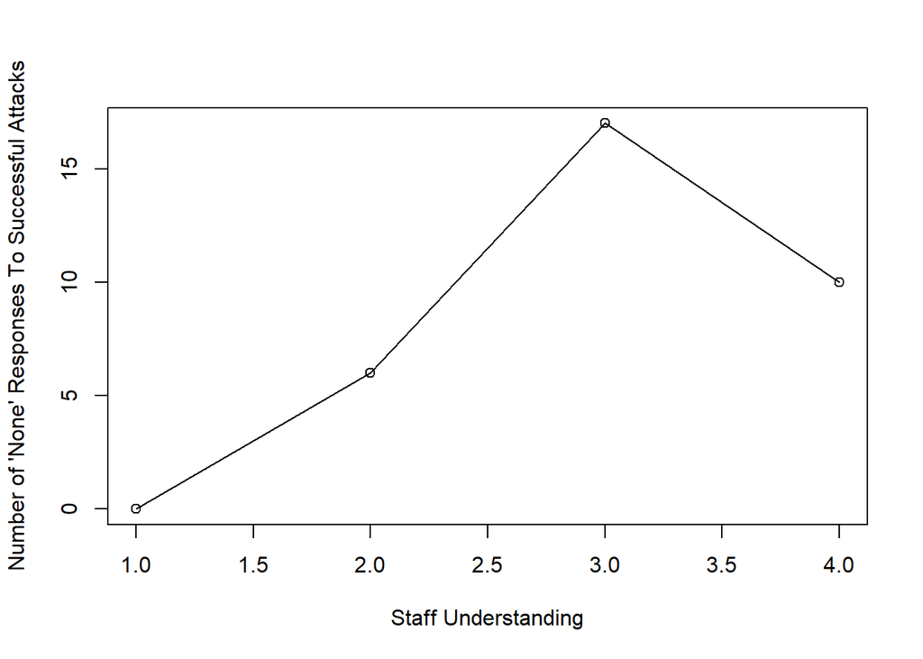

```r
points <- c(0,6,17,10)
plot(points, type="o", xlab = "Staff Understanding", ylab="Number of 'None' Responses To Successful Attacks")
```

By looking at the graph, there is a steady increase in the number of “Nones” as the levels of how well understood the staff is in protecting themselves against cybercrime. While “Quite Well Understood” has more “None”s than “Very Well Understood” this can be attributed to the fact that “Quite Well Understood” has over twice the entries as “Very Well Understood”.

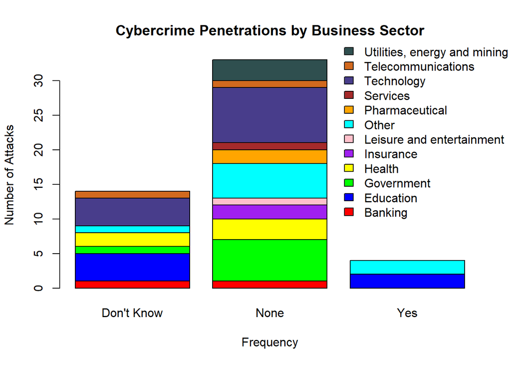

```r
tab <- table(data$Sector, data$SuccessfulPenetration)
colors <- c("red", "blue", "green", "yellow", "purple", "pink", "cyan", "orange", "brown", "darkslateblue", "chocolate", "darkslategray", "black", "white")
barplot(tab, main="Cybercrime Penetrations by Business Sector", xlab="Frequency", ylab="Number of Attacks", col=colors,legend = rownames(tab), args.legend=list(x="topright",bty="n",inset=c(-0.08,-0.1)))
```

Looking at these results we can see which industries are sectors are targeted by cybercrime, and within those sectors which are the most successful at preventing these attacks. It’s interesting to note that technology companies rank high amongst those that aren’t successfully penetrated by cybercriminals. It could be that this is due to a higher level I.T. Priority and Staff Understanding within this sector, which concludes what was observed with the contigency tables.

# Analysis

### Chi-squared Tests

1. **A Chi-squared Test for association between a Companies I.T. Priority and Successful Penetrations**

```
##
##  Pearson's Chi-squared test
##
## data:  ctable
## X-squared = 4.4979, df = 8, p-value = 0.8096
```

```
##
##  Fisher's Exact Test for Count Data
##
## data:  tab
## p-value = 0.6051
## alternative hypothesis: two.sided
```

The p-value from our Chi-squared test tells us that we fail to reject the null hypothesis since the p-value is much larger than our significance level, which is further confirmed by the Fisher’s Exact Test. The Fisher’s Exact Test is used since we know the sample size of my data is on the small size. Since the Fisher’s Exact calculates the association in a way that’s friendlier with my small data set, it’s a useful comparison tool. In the event that the Chi-sqaured result says to fail to reject the null, and the Fisher’s Exact disagrees, it’s best to listen to the result of the Fisher’s Exact.

With this information, we can conclude that there is no association between I.T. Priority and Successful Penetrations.

2. **A Chi-squared Test for association between a Companies Staff Understanding and Successful Penetrations**

```
##
##  Pearson's Chi-squared test
##
## data:  ctable
## X-squared = 4.8603, df = 6, p-value = 0.5619
```

```
##
##  Fisher's Exact Test for Count Data
##
## data:  tab
## p-value = 0.5189
## alternative hypothesis: two.sided
```

Like with I.T. Priority, the p-value of this Chi-squared test, when compared to our statistical significance of 0.05, also tells us that there is no association between these two variables and is further concluded with the Fisher’s Exact Test. This also does not support what we initially observed during our exploration.

3. **A Chi-squared Test for association between a Companies I.T. Expenditure and Successful Penetrations**

```
##
##  Pearson's Chi-squared test
##
## data:  ctable
## X-squared = 21.995, df = 14, p-value = 0.07871
```

```
##
##  Fisher's Exact Test for Count Data
##
## data:  tab
## p-value = 0.08966
## alternative hypothesis: two.sided
```

The p-value of this Chi-squared test tells us that there is a small association between these two variables since the p-value is less than our Fisher’s Exact Test. Since we know that my data size is too small to accurately portray what I’m analyzing, it’s best to use the result of the Fisher’s Exact Test as a comparison. This is because the Fisher’s Exact ignores some of the assumptions that the Chi-Squared test makes, ultimately making it better for my undersized sample.

From this find, we can conclude that the association between I.T. Expenditure and Cybercrime Success is greater than the other countermeasures analyzed so far, however the association is small. With more data we might be able to see a true association result in this category. When running this test without pruning the 2 rows off that brings our sample size from 53 to 51, we get positive results of an association since the Fisher’s Exact returns a value of 0.04:

```
##
##  Fisher's Exact Test for Count Data
##
## data:  tab
## p-value = 0.04458
## alternative hypothesis: two.sided
```

### Pearson Contingency Coefficient Tests

1. **A Contingency Coefficient Test for correlation between a Companies I.T. Priority and Successful Penetrations**

```
## X-squared
## 0.2821559
```

Looking at the results of our Contingency Coefficient test, we can see that we get a value well under 0.5. This tells us that the number of Successful Penetrations is not contigenct on the I.T. Priority of a company. This does not support what I observed with the contingency tables.

2. **A Contingency Coefficient Test for correlation between a Companies Staff Understanding and Successful Penetrations**

```
## X-squared
## 0.2923655
```

When observing the results of my second Contingency Coefficient test, we can see that we get another value under 0.5. From this we can conclude that the number of penetrations is not associated with how well the staff understands how to protect themselves against cybercriminals. This also doesn’t support our initial observations

3. **A Contingency Coefficient Test for correlation between a Companies I.T. Expenditure and Successful Penetrations**

```
## X-squared
## 0.5452093
```

In this Contingency Coefficient test, we can see that our value is over 0.5. This tells us that these variable do associate with eachother. There seems to be a direct association between I.T. Expenditure and the number of Successful Penetration, even if that association is small.

### Cramer’s V Test

1. **A Cramer’s V Association Test for correlation between a Companies I.T. Priority and Successful Penetrations**

```
## X-squared
## 0.2079643
```

The result of our Cramer’s V Test tells us that there is little association between I.T. Priority and Penetration by Cybercriminals.

2. **A Cramer’s V Association Test for correlation between a Companies Staff Understanding and Successful Penetrations**

```
## X-squared
## 0.2161792
```

The result of our second Cramer’s V Test tells us that there is little association between Staff Understanding and Penetration by Cybercriminals.

3. **A Cramer’s V Association Test for correlation between a Companies I.T. Expenditure and Successful Penetrations**

```
## X-squared
## 0.4598846
```

The results of our third Cramer’s V test tells us that there is also little association between I.T. Expenditure and Successful Penetration by Cybercriminals. However, there is more association here than with our other two variables. Overall, the association is still in the low to medium range.

### Review of Analysis (Conclusions)

As mentioned before, my power analysis concluded that my sample size was too small for me to properly calculate the association with these variables, so my results should be taken with some skepticism. What my results do create is an idea at what the results of a properly sampled analysis might find. With a larger sample size, we might find the association between I.T. Priority/Employee Understanding and Successful Penetrations to be more impactful. This would help answer the question that current countermeasures can properly protect companies from successful cyber penetrations.

# Next Question

After looking at my analysis, it seems like the biggest impact on successful cybercriminal penetration is the I.T. Expenditure of a company. I think the best question to ask is why is this variable the most impactful? Is it because it’s truly great at stopping cybercriminals from attacking a system, or because there is a higher volume of attackers trying their hand at a nicer, more expensive, defense system. We know from my initial explorations that the Education sector is the most vulnerable to these attacks. I think this is the next logical step because knowing this will help companies better prepare through monetary investment in order to stop cybercriminals from penetrating their systems and getting ahold of their data.

# References Cited

- Gogolin, G. The Digital Crime Tsunami: Digital Investigation.**7**: 3-8. (2010).
- McGuire, M. and Dowling, S. *Cyber crime: A review of the evidence* Research Report **75**: 1-34.(2013).
- Vaidya, R. Cyber Security Breaches Survery 2018. Department for Digital, Culture, Media & Sport.(2018)
- Singer, P.W. and Friedman, A. *Cybersecurity and Cyberwar What Everyone Needs To Know*. Oxford University Press. New York, NY. 268 pp. (2014).
- Libicki, M., Senty, D. and Pollak, J. *H4cker5 Wanted An Examination of the Cybersecurity Labor Market*. Rand Corporation. ebook. 82 pp. (2014).